# How to visualise data in R

Published

Last updated: 07/10/2026 14:28

A compendium of code for visualising data in R (primarily using `ggplot2`).

Note: this guide uses built-in datasets from the following, amongst others:

- [`palmerpenguins`](https://allisonhorst.github.io/palmerpenguins/)
- [`gcookbook`](https://cran.r-project.org/web/packages/gcookbook/gcookbook.pdf)
- [`ggplot2`](https://ggplot2.tidyverse.org/reference/#data)
- [`gapminder`](https://cran.r-project.org/web/packages/gapminder/readme/README.html)

# 1 Structure of a `ggplot`

- **Aesthetics** describe mapping between visual elements and variables in the data, e.g. x-axis may be mapped to “time_point”, while colour may be mapped to “gender”.
- **Geoms** are the type of visual ‘marks’ on a plot such as lines, points, or bars (covered under Plot types below): they are geometrical objects used to represent data.

```r
data %>%
  ggplot(aes(x = ind_var,
             y = dep_var)) +
  geom_point(aes(colour = factor(grouping_var)),
             size = 1.5)
```

If you want to add a global attribute (e.g. to apply to all points, lines, or whatever), specify this **outside of `aes()`** because it is not a mapping (it doesn’t relate to something in the dataframe itself).

# 2 Plot types

## 2.1 Points

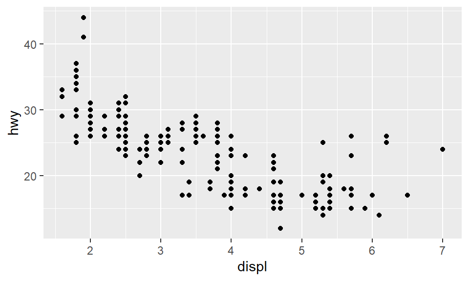

```r
mpg %>%
  ggplot(aes(x = displ, y = hwy)) +
  geom_point(size = 1.5,
             position = "identity")
```

This masks the picture because there are overlapping points. Changing `position` to `"jitter"`:

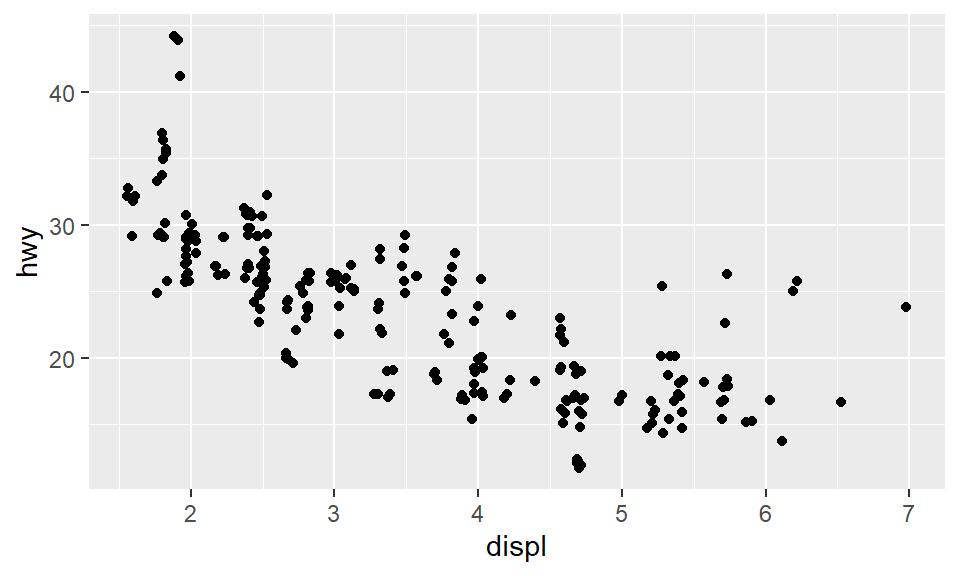

Adding mappings for colour and shape:

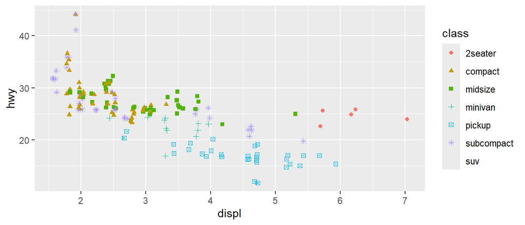

```r
mpg %>%
  ggplot(aes(x = displ, y = hwy)) +
  geom_point(aes(colour = class,
                 shape = class),
             size = 1.5,
             position = "jitter")
```

Note that this can also be written as:

```r
mpg %>%
  ggplot() +
  geom_point(aes(x = displ, y = hwy,
                 colour = class,
                 shape = class),
             size = 1.5)
```

### 2.1.1 Point shapes

Note: the `fill` attribute can be changed to any colour for shapes 21 to 24.

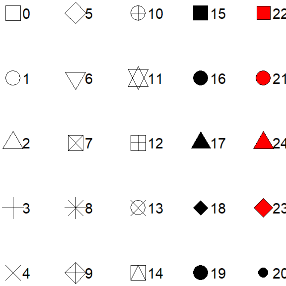

### 2.1.2 For large datasets

Use `geom_bin_2d`

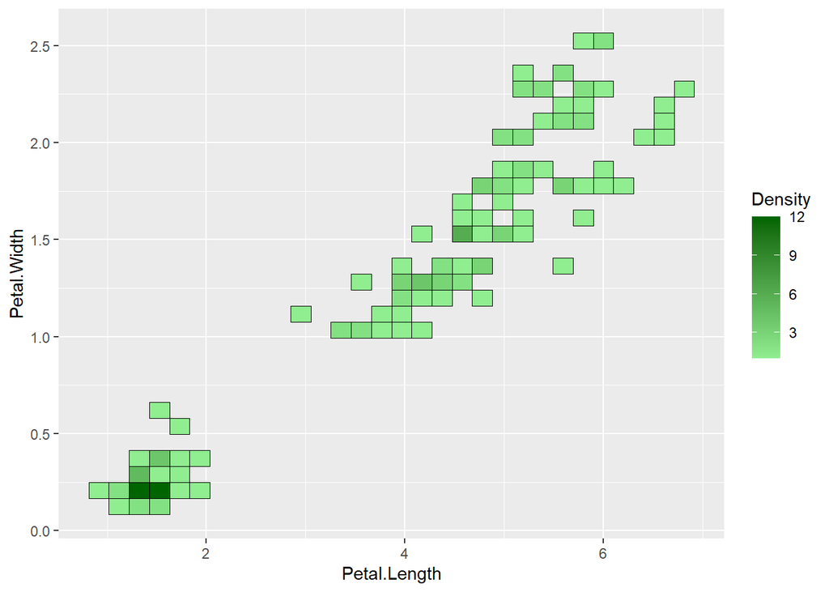

```r
# by default, bins is set at 30. Specifying binwidth will overwrite this.
ggplot(iris, aes(x = Petal.Length, y = Petal.Width)) +
  geom_bin_2d(aes(fill = after_stat(count)),  color = "black", bins = 30) +
  scale_fill_gradient(name = "Density", low = "lightgreen", high = "darkgreen")
```

## 2.2 Lines

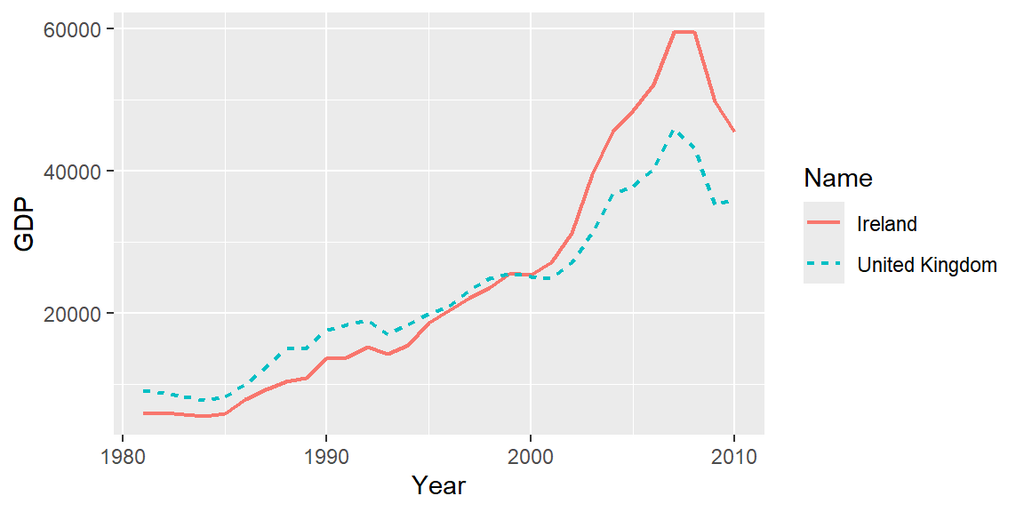

```r
gcookbook::countries %>%
  filter(Name %in% c("United Kingdom", "Ireland") & Year > 1980) %>%
  ggplot(aes(x = Year, y = GDP)) +
  geom_line(aes(colour = Name,
                linetype = Name),
            linewidth = 0.8)
```

```r
# to add arrows to the ends of lines, add this to geom_line:
# arrow = arrow(length = unit(0.25, "cm"), ends = "last", type = "closed")
```

Adding a line of best fit

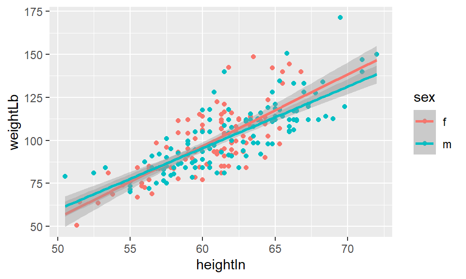

```r
gcookbook::heightweight %>%
  ggplot(aes(x = heightIn, y = weightLb)) +
  geom_point(aes(colour = sex)) +
  geom_smooth(method = "lm", # or "loess"
              fullrange = T,
              aes(colour=sex))
```

Use `geom_segment` to add lines from points to fitted regression slope using some dummy data:

| x | y | Fitted |
| --- | --- | --- |
| 12 | 10 | 11.015252 |
| 3 | 2 | 5.411141 |
| 5 | 4 | 6.656499 |
| 3 | 9 | 5.411141 |
| 1 | 5 | 4.165782 |
| 15 | 13 | 12.883289 |

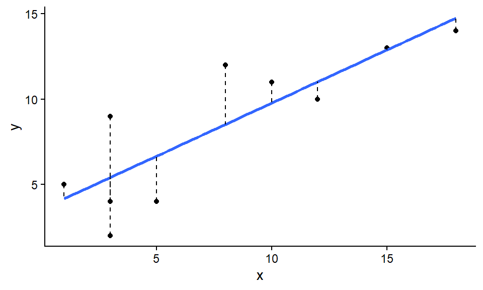

```r
ggplot(df, aes(x = x, y = y)) +
  geom_point() +
  theme_classic() +
  geom_smooth(method = "lm", se = F) +
  geom_segment(aes(x = x, y = y,
                   xend = x, yend = Fitted),
               linetype = "dashed")
```

### 2.2.1 Linetypes

Example usage: `linetype = "dashed"`

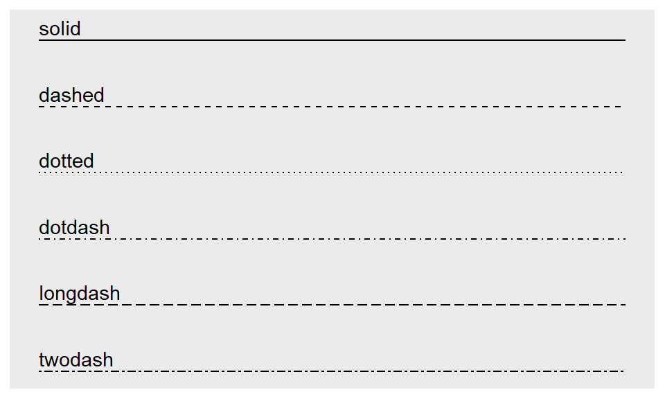

## 2.3 Bars

### 2.3.1 Simple bar chart

- `geom_col` leaves the data as it is and merely represents values already in the dataframe.
- `geom_bar` uses `stat_count` by default to derive new values from the data. As a result, `geom_bar` doesn’t expect a y-value, but if you provide one then you are telling it to forgo the aggregation it would have done anyway with `stat_count`.

Using `stat = "count"`

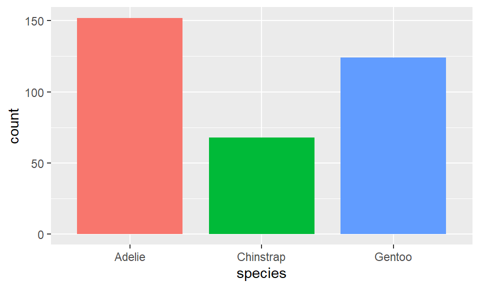

```r
palmerpenguins::penguins %>%
  ggplot(aes(x = species, fill = species)) +
  geom_bar(stat = "count", # default - can be omitted
           width = 0.8,
           show.legend = F)
```

Using `stat = "identity"` to represent pre-calculated summary stats.

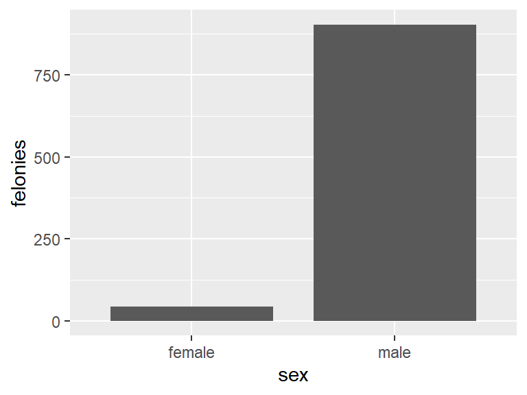

```r
gcookbook::drunk %>%
  pivot_longer(c(2:6)) %>%
  group_by(sex) %>%
  summarise(felonies = sum(value)) %>%
  ggplot(aes(x = sex, y = felonies)) +
  geom_bar(stat = "identity", width = 0.8)
```

You should also use `stat_identity` if you want to **reorder** bars in descending order. The syntax for `reorder` is `reorder(what, by_what)`. Here, `-n` means descending order.

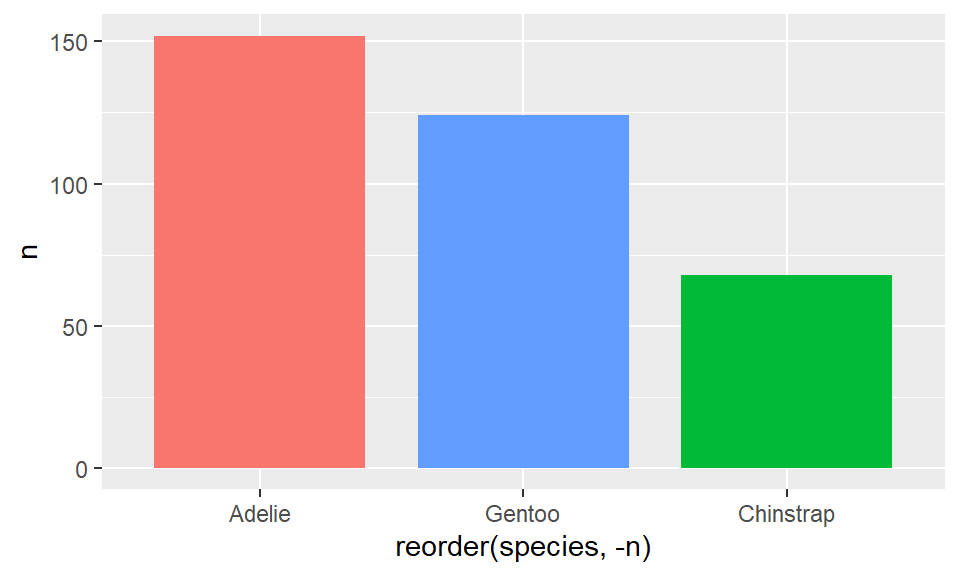

```r
palmerpenguins::penguins %>%
  group_by(species) %>%
  summarise(n = n()) %>%
  ggplot(aes(reorder(species, -n), n)) +
  geom_bar(stat = "identity", width = 0.8,
           aes(fill = species),
           show.legend = F)
```

### 2.3.2 Dodged bar chart

Dodged bars represent geoms for each level of some factor (here, sex), arranged side by side for ease of comparison. Note that this dataset has NAs. To remove these before graphing, use `drop_na`.

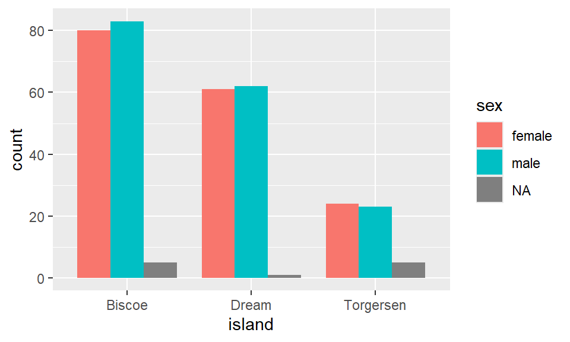

```r
palmerpenguins::penguins %>%
  # drop_na(sex) %>%
  ggplot(aes(x = island, fill = sex)) +
  geom_bar(position = position_dodge(),
           width = 0.8)
```

### 2.3.3 Stacked bar chart

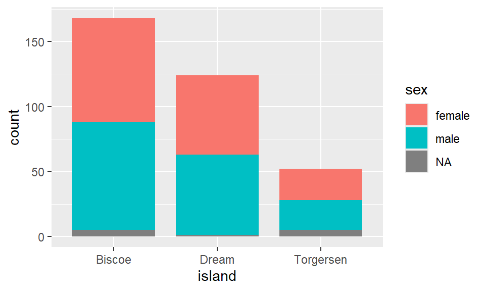

```r
palmerpenguins::penguins %>%
  ggplot(aes(x = island, fill = sex)) +
  geom_bar(position = position_stack(),
           width = 0.8)
```

## 2.4 Proportional stacked bar

### 2.4.1 When there is an explicit y-value

Use this recipe if your dataframe already has a variable representing the y-value (e.g. `count`). Notice use of `stat_identity`.

```r
prop_df
```

| group | type | count |
| --- | --- | --- |
| a | x | 11091 |
| a | y | 4583 |
| b | x | 3974 |
| b | y | 10984 |

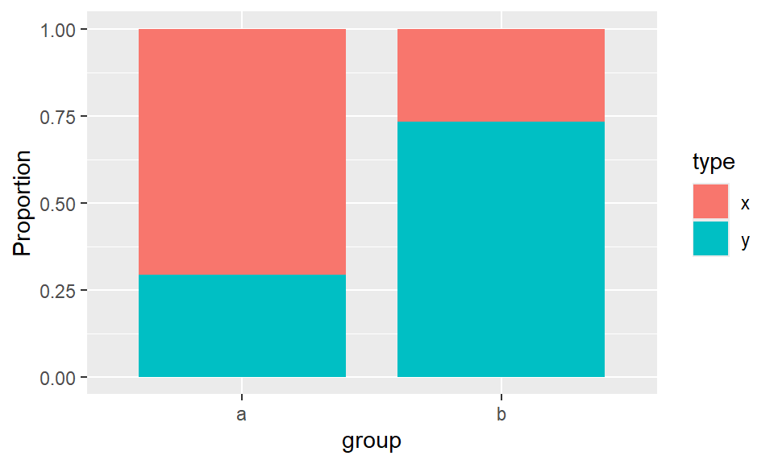

```r
prop_df %>%
  ggplot(aes(x = group, y = count, fill = type)) +
  geom_bar(position = position_fill(), stat = "identity", width = 0.8) +
  ylab("Proportion")
```

### 2.4.2 When there is no explicit y-value (i.e. counts of a factor)

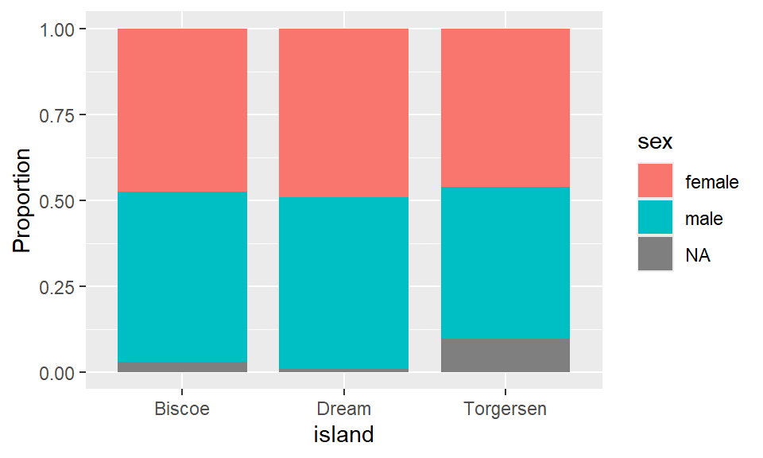

```r
palmerpenguins::penguins %>%
  ggplot(aes(x = island, fill = sex)) +
  geom_bar(position = position_fill(),
           width = 0.8) +
  ylab("Proportion")
```

Text is dealt with later on, but to add figures to the above figure you need to manually calculate proportions for each cell first and then pipe this into ggplot. The recipe below also has some nifty code for converting decimals into nicely formatted percentages.

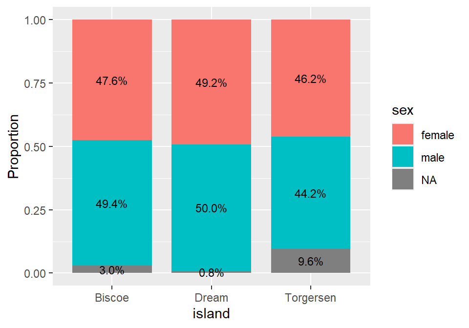

```r
palmerpenguins::penguins %>%
  group_by(island, sex) %>%
  summarise(n = n()) %>% # you may need to use sum() here instead of n()
  mutate(prop = n / sum(n)) %>%
  ggplot(aes(x = island, y = prop, fill = sex)) +
  geom_bar(stat = "identity", width = 0.8) +
  geom_text(aes(label = paste0(sprintf("%.1f", prop * 100), "%")),
            position = position_stack(vjust = 0.5),
            size = 3,
            show.legend = F) +
  ylab("Proportion")
```

```r
# note: to change decimal places, "%.0f", "%.2f" etc
```

## 2.5 Plotting summary data

Use `stat_summary` to plot statistical summaries like sums or means. This requires raw-format data (i.e. which hasn’t already been summarised) as `ggplot` does the calculations internally. See Section 4 for more information.

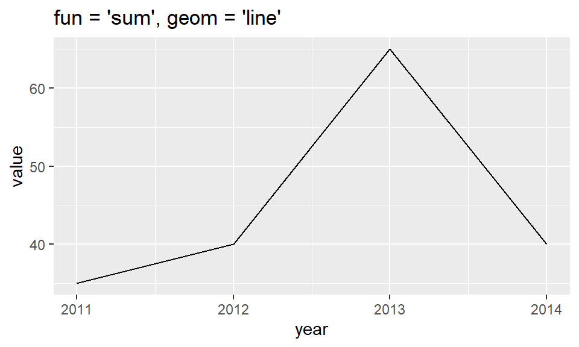

```r
df %>%
  ggplot(aes(x=year, y=value)) +
  stat_summary(fun = "sum", geom = "line")  +
  ggtitle("fun = 'sum', geom = 'line'")
```

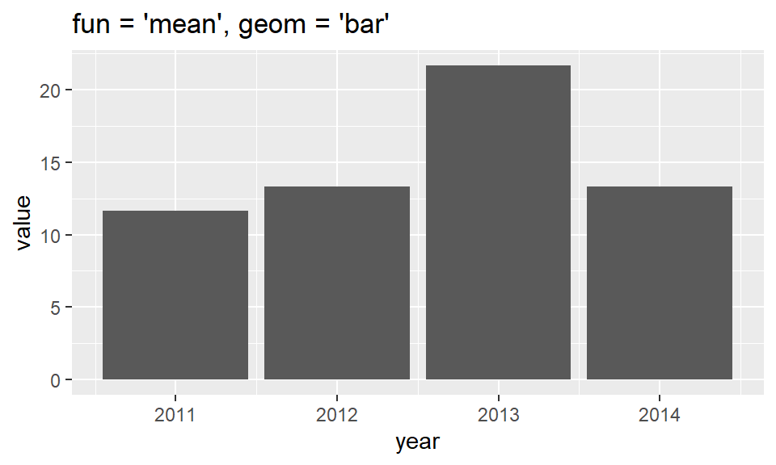

```r
df %>%
  ggplot(aes(x=year, y=value)) +
  stat_summary(fun = "mean", geom = "bar") +
  ggtitle("fun = 'mean', geom = 'bar'")
```

## 2.6 Boxplot

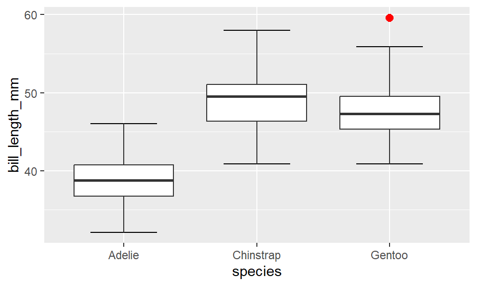

```r
palmerpenguins::penguins %>%
  ggplot(aes(x = species, y = bill_length_mm)) +
  # this part produces just the I-shaped lines
  stat_boxplot(
    geom ='errorbar',
    width = 0.5) +
  # this part produces the boxes
  geom_boxplot(
    notch = F,
    outlier.color = "red",
    outlier.size = 2.5
  )
```

It’s also possible to add labels to boxplots showing the different quartiles.

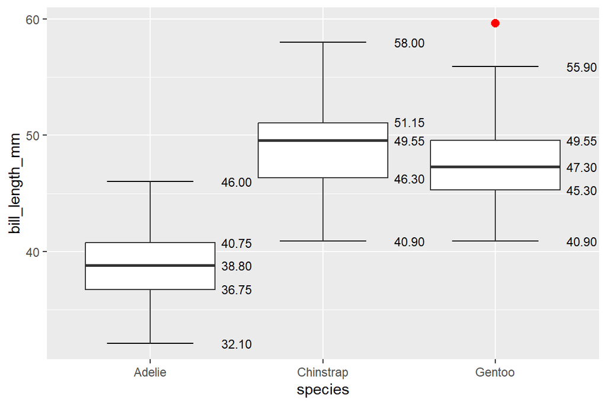

```r
palmerpenguins::penguins %>%
  ggplot(aes(x = species, y = bill_length_mm)) +
  # this part produces just the I-shaped lines
  stat_boxplot(
    geom ='errorbar',
    width = 0.5) +
  # this part produces the boxes
  geom_boxplot(
    notch = F,
    outlier.color = "red",
    outlier.size = 2.5
  ) +
  stat_summary(
    aes(label = sprintf("%0.2f", ..y..)),
    geom = "text",
    fun = function(y) boxplot.stats(y)$stats,
    position = position_nudge(x = 0.5, y = 0.006), # raised data labels up as they were not legible on top of the boxplot itself
    #position = position_nudge(x = 0.1, y = 0.006),
    size = 3)
```

## 2.7 Violin plot

A more sophisticated version of a boxplot using density curves to show the distribution for the entire range of values.

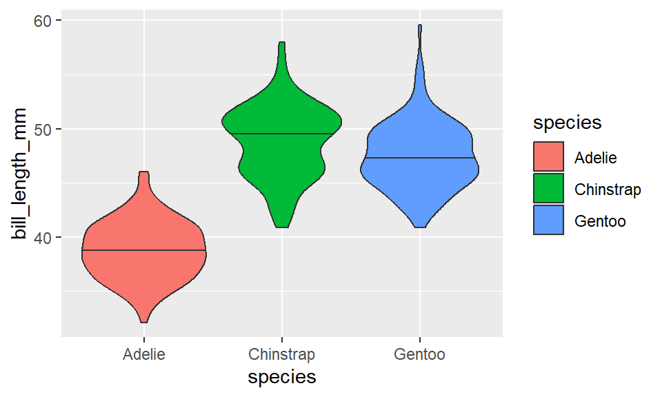

```r
palmerpenguins::penguins %>%
  ggplot(aes(x = species, y = bill_length_mm)) +
  geom_violin(aes(fill = species),
              quantiles = c(0.5),
              quantile.linetype = 1)
```

## 2.8 Dotplot

For when there isn’t a huge amount of data. Each dot represents a single observation.

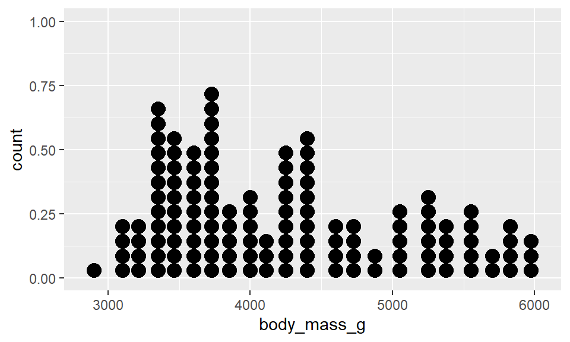

```r
palmerpenguins::penguins %>%
  sample_n(125, replace=F) %>%
  ggplot(aes(x=body_mass_g)) +
  geom_dotplot(dotsize = 1, width = 1)
```

## 2.9 Histogram

For when there’s more data, or binning is better. This only requires an x-axis value. `geom_histogram` usually does a good job of setting the `bindwidth` automatically but this can be manually controlled.

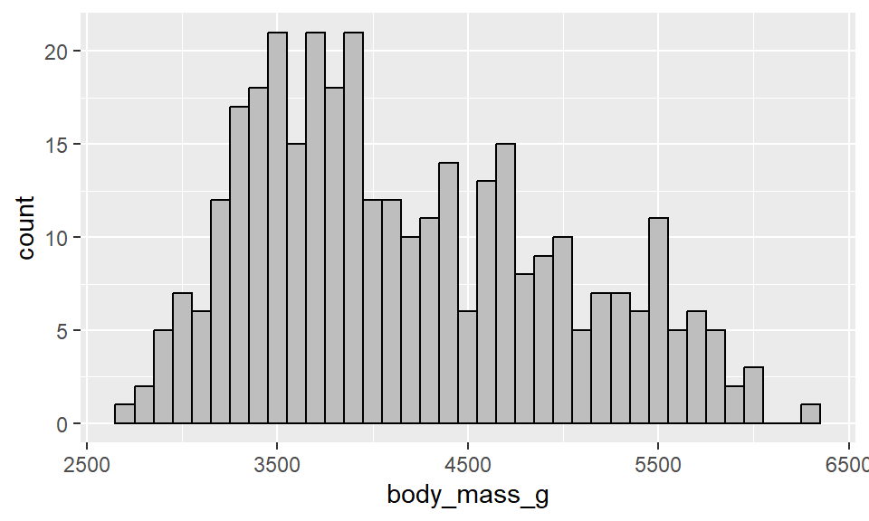

```r
palmerpenguins::penguins %>%
  ggplot(aes(x = body_mass_g)) +
  geom_histogram(binwidth = 100,
                 fill = "grey",
                 colour = "black")
```

Recipe: overlay separate histograms for levels of a factor (here, `cut`). By default, `geom_histogram` will stack bars if there are multiple groups but you can change this by changing `position` to `identity`:

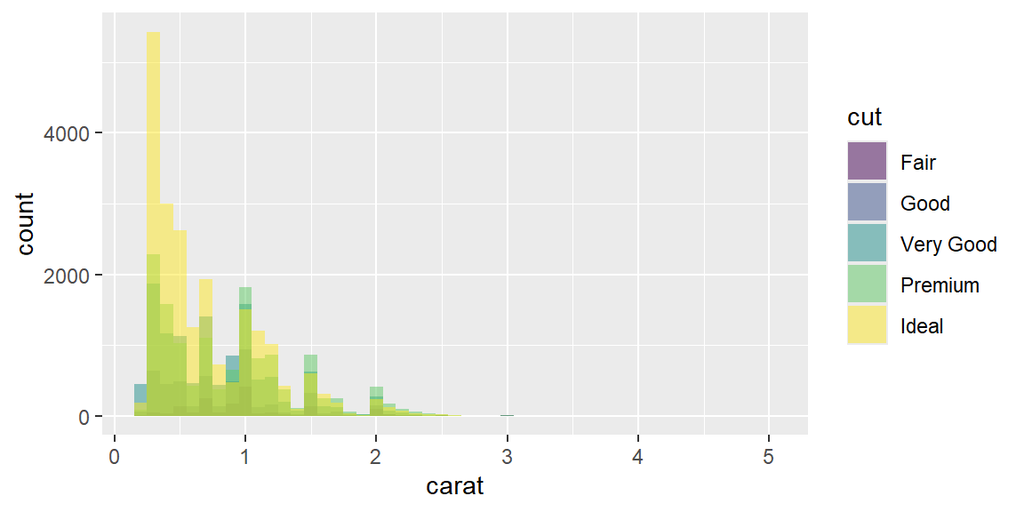

```r
ggplot2::diamonds %>%
  ggplot(aes(x = carat, fill = cut)) +
  geom_histogram(binwidth = 0.1, position = "identity", alpha = 0.5)
```

Sometimes you may want to produce a range of histograms for each level of a factor. Here is a recipe for a function to iterate through multiple histograms, by group, using `purrr`:

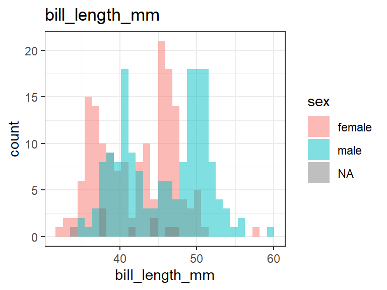

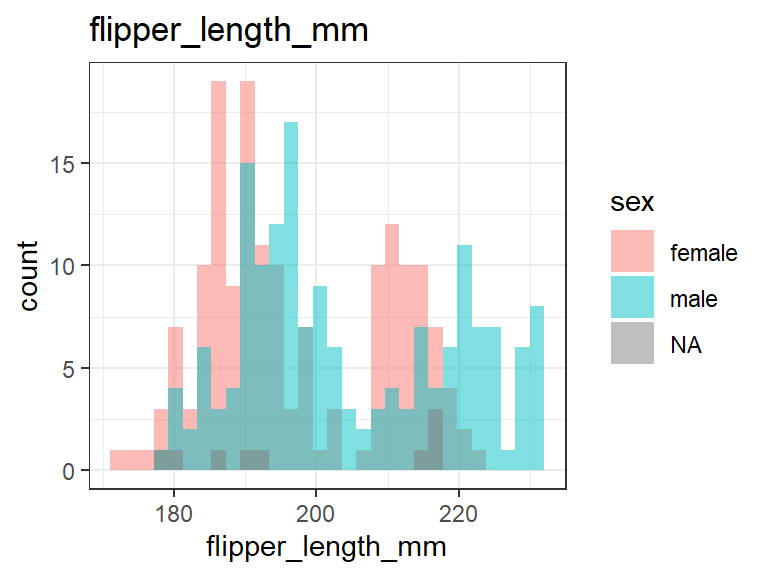

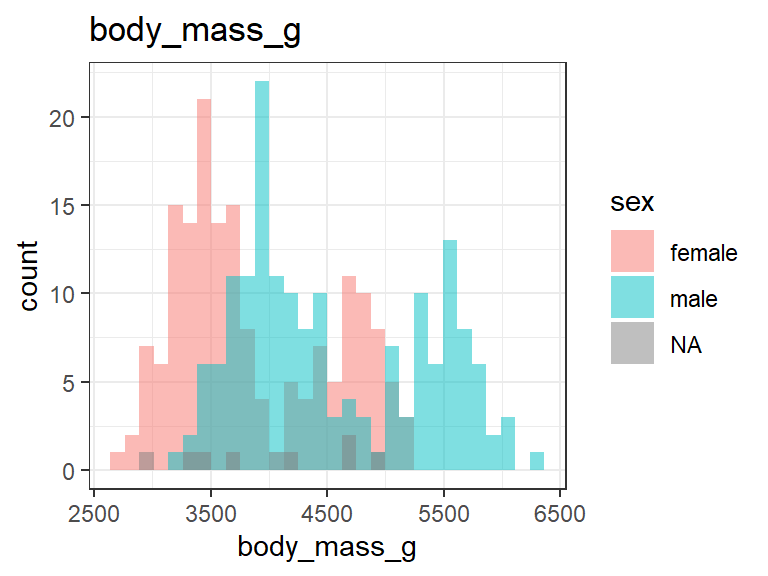

```r
# firstly make a vector of all the variable names you want to plot
vars = c("bill_length_mm", "flipper_length_mm", "body_mass_g")

# then create a custom graphing function
hist_fun = function(data, x, y) {
  ggplot(data, aes(x = .data[[x]], fill = .data[[y]]) ) +
    geom_histogram(alpha = 0.5, position = "identity") +
    theme_bw() +
    ggtitle(x)
}

# use purrr::map to cycle through vars to produce plots, with a constant grouping factor
purrr::map(vars, ~ hist_fun(data = palmerpenguins::penguins, .x, "sex") )
```

## 2.10 Density

For large amounts of data. Use `bw` argument to change bandwidth (e.g. if you want more smoothing).

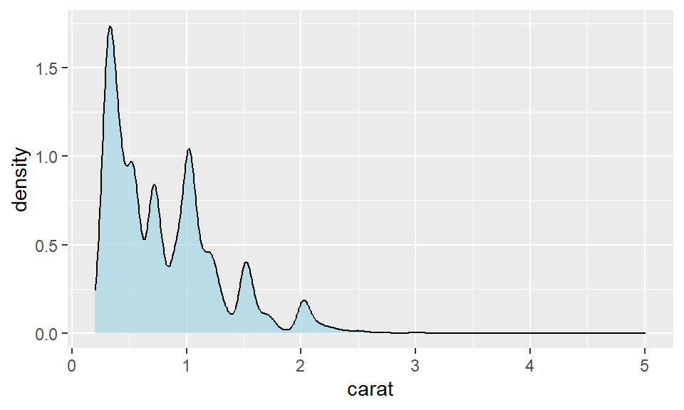

```r
ggplot2::diamonds %>%
  ggplot(aes(x = carat)) +
  geom_density(bw = 0.05, fill = "lightblue",
               alpha = 0.8)
```

As with the multiple-group histogram example above, you may want to overlay density distributions for levels of a factor.

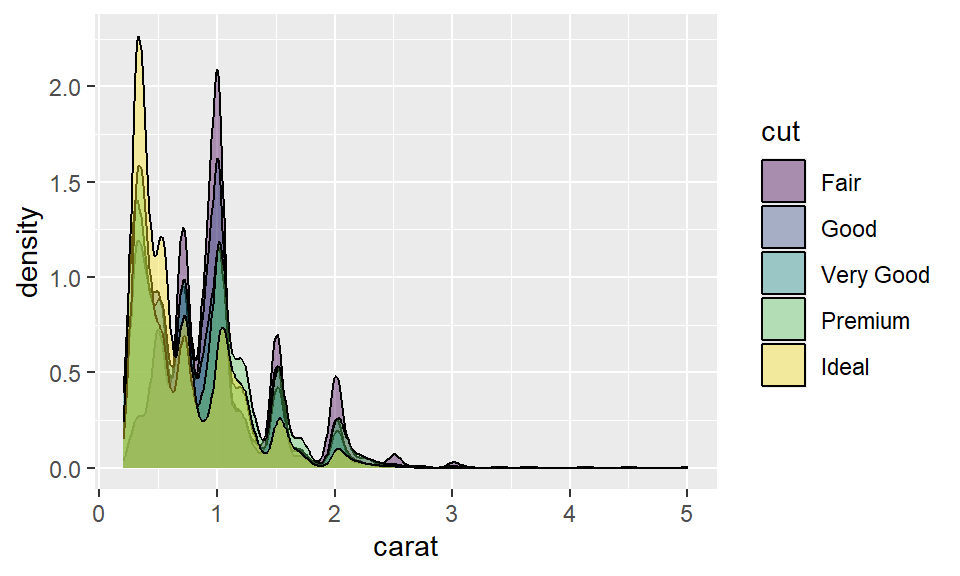

```r
ggplot2::diamonds %>%
  ggplot(aes(x = carat, fill = cut)) +
  geom_density(bw = 0.05, alpha = 0.4)
```

## 2.11 Rug plot

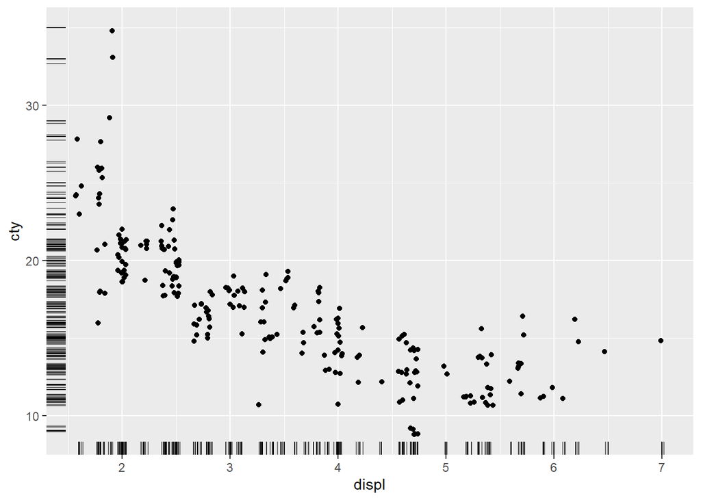

```r
mpg %>%
  ggplot(aes(displ, cty)) +
   geom_jitter() +
  geom_rug(alpha = 1/2, position = "jitter") +
  geom_rug()
```

## 2.12 Pie

Everyone knows that pie charts are illegal in the world of data visualisation, but here’s a recipe just in case…

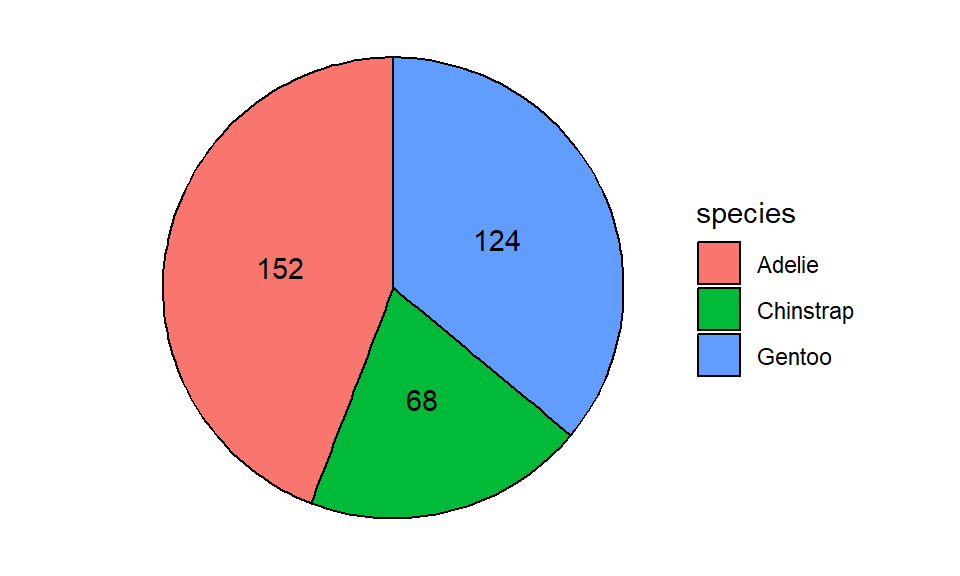

```r
palmerpenguins::penguins %>%
  count(species) %>%
  ggplot(aes(x = "", y = n, fill = species)) +
  geom_col(color = "black") +
  coord_polar(theta = "y") +
  geom_text(aes(label = n),
            position = position_stack(vjust = 0.5),
            show.legend = F) +
  theme_void()
```

## 2.13 Sankey

This recipe produces an interactive html Sankey chart using the `networkD3` package. It may take a little set up beforehand according to the data you have.

```r
links = data.frame(
  Var1 = c("Failed_Phonics", "Passed_Phonics", "Failed_Phonics", "Passed_Phonics"),
  Var2 = c("Failed_KS2", "Failed_KS2", "Passed_KS2", "Passed_KS2"),
  Freq = c(25114, 120356, 9019, 585893)
)

colnames(links) <- c("source", "target", "value")

nodes <- data.frame(name = as.factor(c("Failed_Phonics","Passed_Phonics","Failed_KS2","Passed_KS2")))

# Convert the source and target from characters to indices
links$source <- match(links$source, nodes$name) - 1
links$target <- match(links$target, nodes$name) - 1

# create Sankey diagram
networkD3::sankeyNetwork(Links = links,
              Nodes = nodes,
              Source = "source",
              Target = "target",
              Value = "value",
              NodeID = "name",
              fontSize = 12,
              fontFamily = "sans-serif")
```

[interactive chart not shown]

This can be made into a function to be applied iteratively.

```r
# function
sankey_function = function(var1, var2, lab1, lab2, lab3, lab4){

  tab = table(var1, var2)

  links = data.frame(
    Var1 = c(lab1, lab2, lab1, lab2),
    Var2 = c(lab3, lab3, lab4, lab4),
    Freq = c(tab[1,1], tab[2,1], tab[1,2], tab[2,2])
  )

  colnames(links) <- c("source", "target", "value")

  nodes <- data.frame(name = as.factor(c(lab1, lab2, lab3, lab4)))

  links$source <- match(links$source, nodes$name) - 1
  links$target <- match(links$target, nodes$name) - 1

  # create Sankey diagram
  networkD3::sankeyNetwork(Links = links,
                           Nodes = nodes,
                           Source = "source",
                           Target = "target",
                           Value = "value",
                           NodeID = "name",
                           fontSize = 12,
                           fontFamily = "sans-serif")
}


sankey_function(var1 = ela_final$ks4_mfl, var2 = ela_final$ks5_mfl_any,
                lab1 = "ks4_mfl_no", lab2 = "ks4_mfl_yes",
                lab3 = "ks5_mfl_no", lab4 = "ks5_mfl_yes")
```